# Boston Data Set

This dataset contains information collected by the U.S Census Service concerning housing in the area of Boston Mass. It was obtained from the StatLib archive (http://lib.stat.cmu.edu/datasets/boston), and has been used extensively throughout the literature to benchmark algorithms. The dataset is small in size with only 506 cases.

The data was originally published by Harrison, D. and Rubinfeld, D.L. `Hedonic prices and the demand for clean air’, J. Environ. Economics & Management, vol.5, 81-102, 1978.

Possible target: CRIM or MEDV (redo the exercise using MEDV, comment it!)

There are 14 attributes in each case of the dataset. They are: CRIM - per capita crime rate by town ZN - proportion of residential land zoned for lots over 214,000 sq.ft. INDUS - proportion of non-retail business acres per town. CHAS - Charles River dummy variable (1 if tract bounds river; 0 otherwise) NOX - nitric oxides concentration (parts per 10 million) RM - average number of rooms per dwelling AGE - proportion of owner-occupied units built prior to 1940 DIS - weighted distances to five Boston employment centres RAD - index of accessibility to radial highways TAX - full-value property-tax rate per $10,000 PTRATIO - pupil-teacher ratio by town B - 1000(Bk - 0.63)^2 where Bk is the proportion of blacks by town LSTAT - % lower status of the population MEDV - Median value of owner-occupied homes in $1000’s

```r
library(MASS)
data("Boston", package = "MASS")
mod<-lm(crim~.,data=Boston)
summary(mod)
```

```
##
## Call:
## lm(formula = crim ~ ., data = Boston)
##
## Residuals:
##    Min     1Q Median     3Q    Max
## -9.924 -2.120 -0.353  1.019 75.051
##
## Coefficients:
##               Estimate Std. Error t value Pr(>|t|)
## (Intercept)  17.033228   7.234903   2.354 0.018949 *
## zn            0.044855   0.018734   2.394 0.017025 *
## indus        -0.063855   0.083407  -0.766 0.444294
## chas         -0.749134   1.180147  -0.635 0.525867
## nox         -10.313535   5.275536  -1.955 0.051152 .
## rm            0.430131   0.612830   0.702 0.483089
## age           0.001452   0.017925   0.081 0.935488
## dis          -0.987176   0.281817  -3.503 0.000502 ***
## rad           0.588209   0.088049   6.680 6.46e-11 ***
## tax          -0.003780   0.005156  -0.733 0.463793
## ptratio      -0.271081   0.186450  -1.454 0.146611
## black        -0.007538   0.003673  -2.052 0.040702 *
## lstat         0.126211   0.075725   1.667 0.096208 .
## medv         -0.198887   0.060516  -3.287 0.001087 **
## ---
## Signif. codes:  0 '***' 0.001 '**' 0.01 '*' 0.05 '.' 0.1 ' ' 1
##
## Residual standard error: 6.439 on 492 degrees of freedom
## Multiple R-squared:  0.454,  Adjusted R-squared:  0.4396
## F-statistic: 31.47 on 13 and 492 DF,  p-value: < 2.2e-16
```

```r
library(car)
vif(mod)
```

```
##       zn    indus     chas      nox       rm      age      dis      rad
## 2.325094 3.987753 1.094326 4.551563 2.258113 3.100801 4.289041 7.158834
##      tax  ptratio    black    lstat     medv
## 9.195495 1.984489 1.369741 3.561476 3.772856
```

```r
sqrt(vif(mod))>2
```

```
##      zn   indus    chas     nox      rm     age     dis     rad     tax ptratio
##   FALSE   FALSE   FALSE    TRUE   FALSE   FALSE    TRUE    TRUE    TRUE   FALSE
##   black   lstat    medv
##   FALSE   FALSE   FALSE
```

## Best Subset regression

We will now use the package `leaps` to evaluate all the best-subset models.

```r
library(leaps)
regfit.full=regsubsets(crim~.,data=Boston, nvmax=13) ## default is 8
reg.summary=summary(regfit.full)
names(reg.summary)
```

```
## [1] "which"  "rsq"    "rss"    "adjr2"  "cp"     "bic"    "outmat" "obj"
```

```r
plot(reg.summary$cp,xlab="Number of Variables",ylab="Cp")
which.min(reg.summary$cp)
```

```
## [1] 8
```

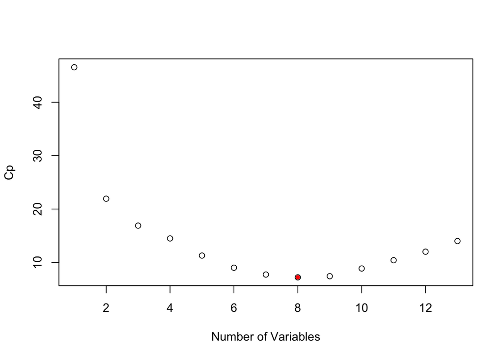

```r
points(8,reg.summary$cp[8],pch=20,col="red")
```

There is a plot method for the `regsubsets` object

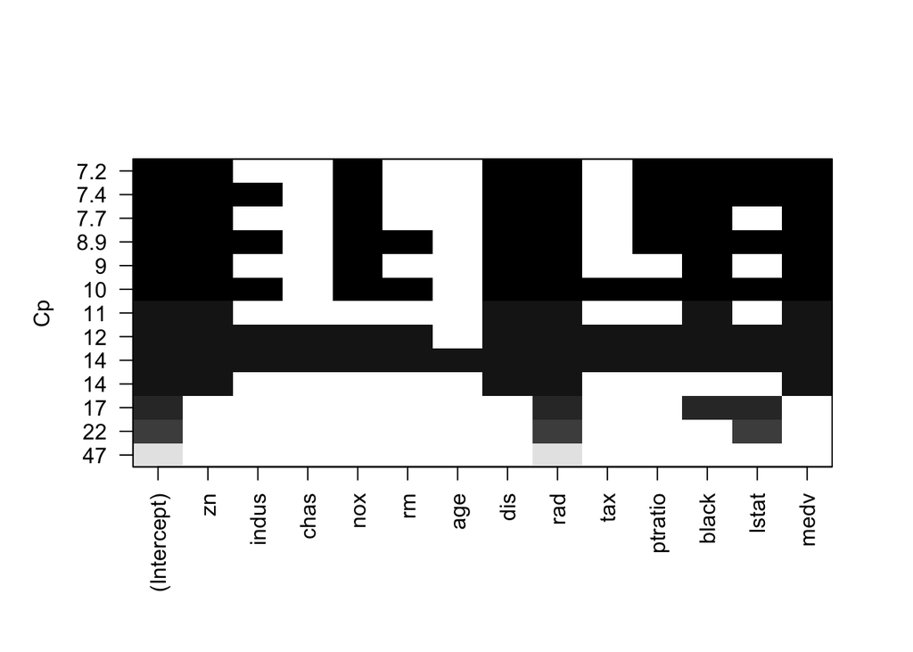

```r
plot(regfit.full,scale="Cp")
```

```r
coef(regfit.full,2)
```

```
## (Intercept)         rad       lstat
##  -4.3814053   0.5228128   0.2372846
```

## Forward Stepwise Selection

Here we use the `regsubsets` function but specify the `method=“forward” option:

```r
regfit.fwd=regsubsets(crim~.,data=Boston,method="forward", nvmax=13)
summary(regfit.fwd)
```

```
## Subset selection object
## Call: regsubsets.formula(crim ~ ., data = Boston, method = "forward",
##     nvmax = 13)
## 13 Variables  (and intercept)
##         Forced in Forced out
## zn          FALSE      FALSE
## indus       FALSE      FALSE
## chas        FALSE      FALSE
## nox         FALSE      FALSE
## rm          FALSE      FALSE
## age         FALSE      FALSE
## dis         FALSE      FALSE
## rad         FALSE      FALSE
## tax         FALSE      FALSE
## ptratio     FALSE      FALSE
## black       FALSE      FALSE
## lstat       FALSE      FALSE
## medv        FALSE      FALSE
## 1 subsets of each size up to 13
## Selection Algorithm: forward
##           zn  indus chas nox rm  age dis rad tax ptratio black lstat medv
## 1  ( 1 )  " " " "   " "  " " " " " " " " "*" " " " "     " "   " "   " "
## 2  ( 1 )  " " " "   " "  " " " " " " " " "*" " " " "     " "   "*"   " "
## 3  ( 1 )  " " " "   " "  " " " " " " " " "*" " " " "     "*"   "*"   " "
## 4  ( 1 )  " " " "   " "  " " " " " " " " "*" " " " "     "*"   "*"   "*"
## 5  ( 1 )  "*" " "   " "  " " " " " " " " "*" " " " "     "*"   "*"   "*"
## 6  ( 1 )  "*" " "   " "  " " " " " " "*" "*" " " " "     "*"   "*"   "*"
## 7  ( 1 )  "*" " "   " "  "*" " " " " "*" "*" " " " "     "*"   "*"   "*"
## 8  ( 1 )  "*" " "   " "  "*" " " " " "*" "*" " " "*"     "*"   "*"   "*"
## 9  ( 1 )  "*" "*"   " "  "*" " " " " "*" "*" " " "*"     "*"   "*"   "*"
## 10  ( 1 ) "*" "*"   " "  "*" "*" " " "*" "*" " " "*"     "*"   "*"   "*"
## 11  ( 1 ) "*" "*"   " "  "*" "*" " " "*" "*" "*" "*"     "*"   "*"   "*"
## 12  ( 1 ) "*" "*"   "*"  "*" "*" " " "*" "*" "*" "*"     "*"   "*"   "*"
## 13  ( 1 ) "*" "*"   "*"  "*" "*" "*" "*" "*" "*" "*"     "*"   "*"   "*"
```

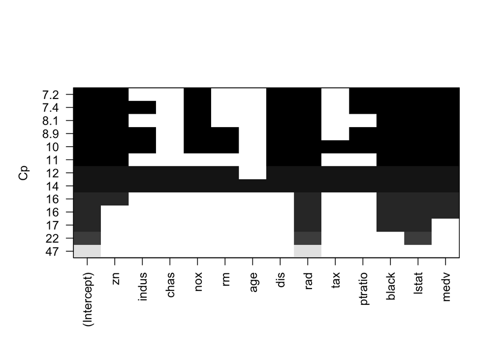

```r
plot(regfit.fwd,scale="Cp")
```

## Model Selection Using a validation Set

Lets make a training and validation set, so that we can choose a good subset model. We will do it using a slightly different approach from what was done in the the book.

```r
dim(Boston)
```

```
## [1] 506  14
```

```r
set.seed(6)
train=sample(seq(506),253,replace=FALSE)
train
```

```
##   [1] 309  10 429 334 184 100 316 323 121 130 194 122  98 414 283 387 149 392
##  [19] 433 342 319  33 138 391  66 217 306  20  64 240 403  77 199 144 268  78
##  [37] 221 298 497  85 179 301 125 471  97 419  13  35 340 107 254 318  29 223
##  [55] 416  18 275 366 418 242 478 396 467  40 127 475 278 394 343 287 436 302
##  [73]  95 354 115  93 118 238  36 260 304 212  47 437 172 367 219 308  89 425
##  [91] 434 401 330 220 373 147 280 407 495 355 390 411 464 402 325  68 131 104
## [109] 389  42  11 203 264  96 132 487 370   7 266 267 454 338 201  59 328 449
## [127] 120 472 408 305 317 259 315  67 488 496  22 364 261  51 256 113 214 395
## [145]  53 175 150 186 202  57 190  63   3 499 447 431 489  25  17 388 384 456
## [163] 385 386 185 422 180 101 162 483 195 307 165  46   6 160  37 189 170 102
## [181] 205 290 269  15 457  73 155 177 123  76 265 143 196 442 430  26 346 423
## [199] 504 438  83  84 227 361 233 129 136 292 310 393 286 358 493 297 245 460
## [217] 371 244 474  61  44 404 158   8  38 159 258  52 296 420 465 229 382  75
## [235] 139  71 337 109 270 116 236 502 142 182 110 231 377 277  14  50 417 412
## [253] 285
```

```r
regfit.fwd=regsubsets(crim~.,data=Boston[train,],method="forward", nvmax=13)
```

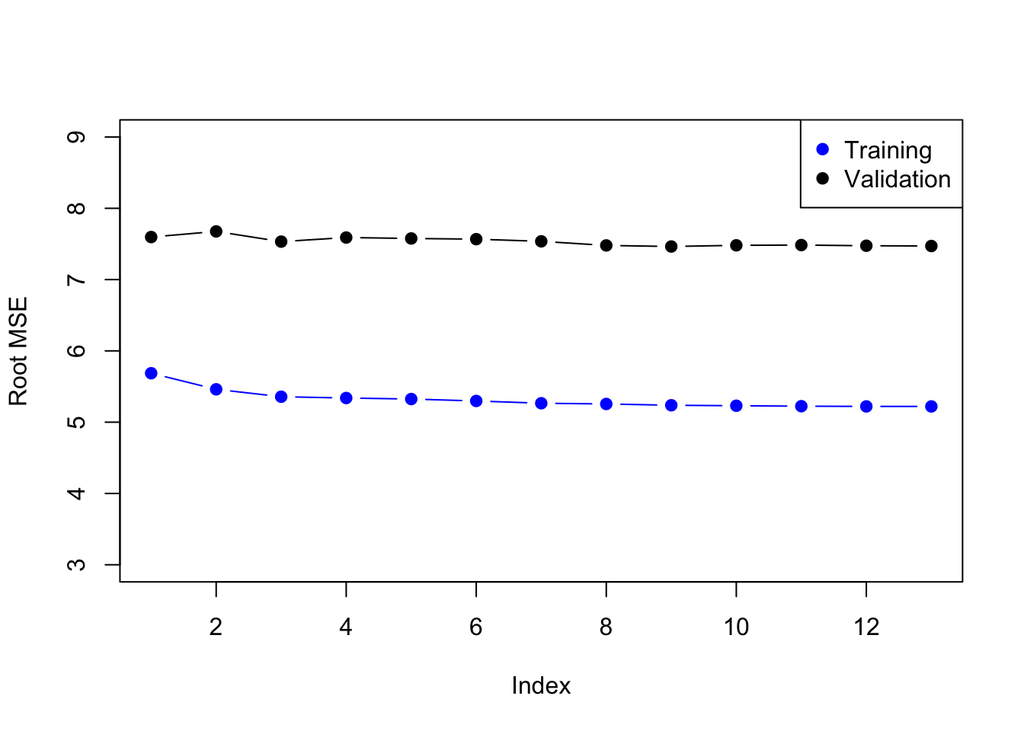

```r
val.errors=rep(NA,13)
x.test=model.matrix(crim~.,data=Boston[-train,])
for(i in 1:13){
  coefi=coef(regfit.fwd,id=i)
  pred=x.test[,names(coefi)]%*%coefi
  val.errors[i]=mean((Boston$crim[-train]-pred)^2)
}
plot(sqrt(val.errors),ylab="Root MSE",ylim=c(3,9),pch=19,type="b")
points(sqrt(regfit.fwd$rss[-1]/253),col="blue",pch=19,type="b")
legend("topright",legend=c("Training","Validation"),col=c("blue","black"),pch=19)
```

We need a function in order to do predict for `regsubsets`

```r
predict.regsubsets=function(object,newdata,id,...){
  form=as.formula(object$call[[2]])
  mat=model.matrix(form,newdata)
  coefi=coef(object,id=id)
  mat[,names(coefi)]%*%coefi
}
```

## Model Selection by Cross-validation

We will do 10-fold cross-validation. Its really easy!

```r
set.seed(11)
folds=sample(rep(1:10,length=nrow(Boston)))
folds
```

```
##   [1] 10  4  4  9  4  3  7 10  4  6  3  4  2  8  7  2  1  3  3  5  9  5 10  3  9
##  [26]  4  7  6  6  3  3  6  2  8  6  1  4  8  6  7  8  9  9  6  7  2  6  3  8  3
##  [51]  4  9  9  2 10  1  2  6  5  5  2  6  4  4  3  6  7  7  1  4  1  2  4  8  7
##  [76]  4  2  2 10  1 10  1  1  6  1  2 10  7  4  6  1  7  9  8  4  1  4  5  4  7
## [101]  9  1  5  4  8  6  9  9  9  6 10  9  3  7  1 10  1  9  1  6  6  2  3  5  5
## [126]  8  3  6  5  3  5  2 10  9  5  6  8  7  3  6  7  7  1  3  6  7  8  7 10  3
## [151]  4  2  9  5  4  9  2  7  6  6  5  1  3  6  9  8  1  2  2  1  4  5  7  8  2
## [176]  5  3  4 10 10 10  1 10  5  2  3  5  6  2  1 10  8  4  3  4  7  5 10  3  8
## [201]  3  5  7  9  7  3 10  3  3  4  6  8  9 10  7  5  1 10  4  2  6  5  2  1 10
## [226] 10  4  1  2  5  7  8  9  5  7  7  7  5  6 10  5  7  8  5  2  5  9  7  3  1
## [251]  2  8  4  4  4 10  1  9  9  9  8  5  7  6  9 10  7  4  6  5  4  1  6  2  6
## [276]  6  1  8  1  8  8  4 10  1  3 10  5  4  6 10 10  4  2  1  8  5  2  6  1  9
## [301]  5  2  8  1  8  2  6  5  2 10  2  8  8  3  8  9  5  2  1  6  8  5 10  7  1
## [326]  2  8  9  5  7  8 10  3  1  9  5  4  9 10  3  4  3  7  9  5  3  4  4 10  1
## [351]  6  4  7  3  1  2  3  6  1  7  5 10  3  2  2  6 10  7  3  1  2  5  1  8  1
## [376]  8  4  9  3  3  8  1  5  4 10  9  1  9  9  2  3  2  4  4  7  8 10  9  6  9
## [401]  4  7 10 10  8  5  5  9  2  1  7  8  2  6  4  8  8 10  1  8  8  4  7  1  7
## [426]  2  1  8  5  1  5  8 10  7  4  3  2  8  6  1  9  9 10  3  9  2  6  6  7  6
## [451]  3 10 10  3  4 10  2  5  4  5  3  7  3  3  7  9  3  8  6  8  1  9  8  3  5
## [476] 10 10  2  2  5 10  3  9  6  4  3  9  7  7  6  6 10  9  9  9  2  2  8  8  5
## [501]  9  5  7  2  6  7
```

```r
table(folds)
```

```
## folds
##  1  2  3  4  5  6  7  8  9 10
## 51 51 51 51 51 51 50 50 50 50
```

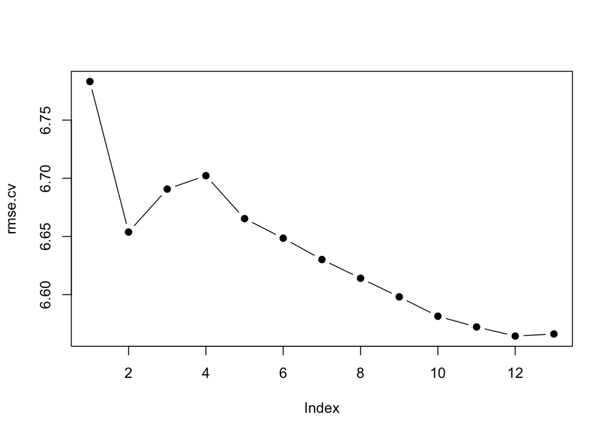

```r
cv.errors=matrix(NA,10,13)
for(k in 1:10){
  best.fit=regsubsets(crim~.,data=Boston[folds!=k,],nvmax=13,method="forward")
  for(i in 1:13){
    pred=predict(best.fit,Boston[folds==k,],id=i)
    cv.errors[k,i]=mean((Boston$crim[folds==k]-pred)^2)
  }
}
rmse.cv=sqrt(apply(cv.errors,2,mean))
plot(rmse.cv,pch=19,type="b")
```

## Ridge Regression and the Lasso

We will use the package `glmnet`, which does not use the model formula language, so we will set up an `x` and `y`.

```r
library(glmnet)
x=model.matrix(crim~.-1,data=Boston)
y=Boston$crim
```

First we will fit a ridge-regression model. This is achieved by calling `glmnet` with `alpha=0` (see the helpfile). There is also a `cv.glmnet` function which will do the cross-validation for us.

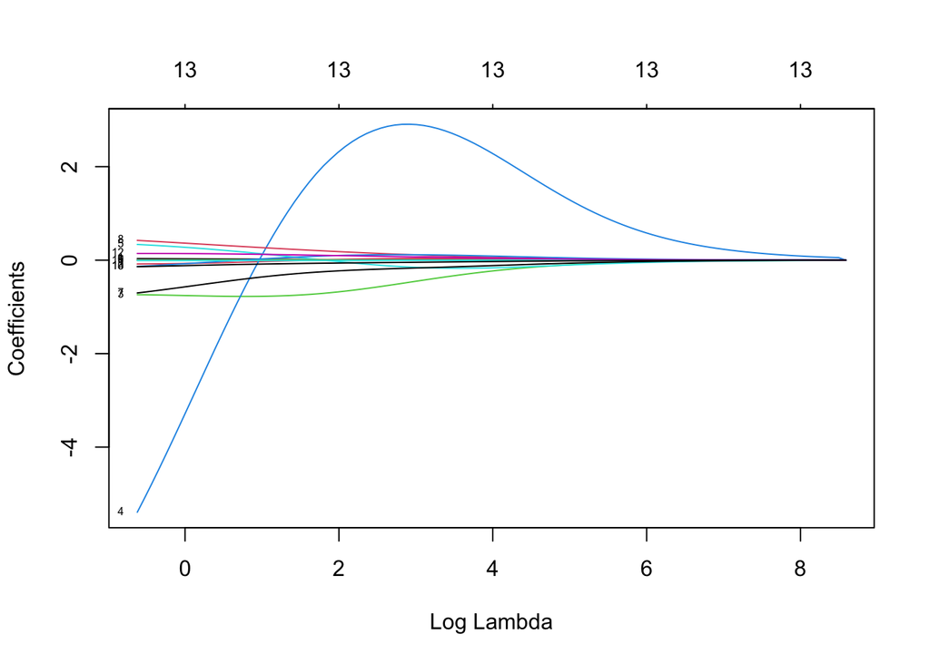

```r
fit.ridge=glmnet(x,y,alpha=0)
plot(fit.ridge,xvar="lambda",label=TRUE)
```

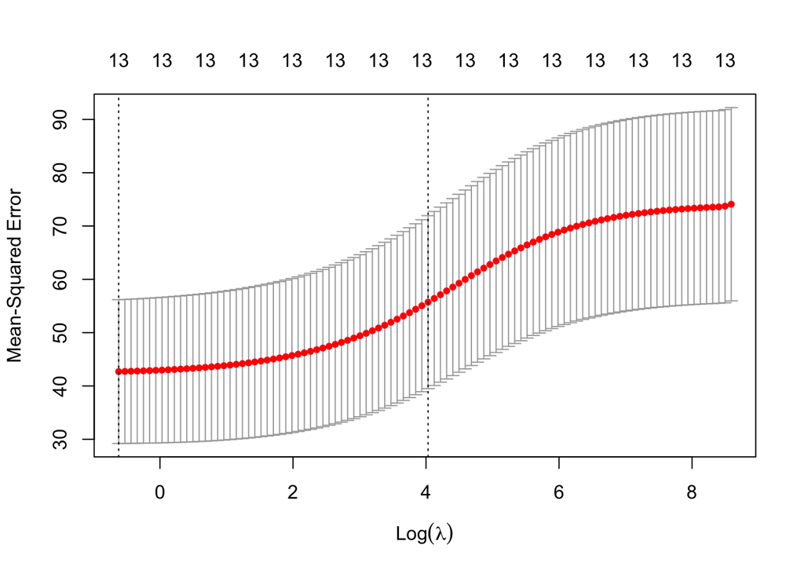

```r
cv.ridge=cv.glmnet(x,y,alpha=0)
plot(cv.ridge)
```

```r
coef(cv.ridge)
```

```
## 14 x 1 sparse Matrix of class "dgCMatrix"
##                        1
## (Intercept)  1.017516870
## zn          -0.002805664
## indus        0.034405928
## chas        -0.225250601
## nox          2.249887495
## rm          -0.162546004
## age          0.007343331
## dis         -0.114928730
## rad          0.059813843
## tax          0.002659110
## ptratio      0.086423005
## black       -0.003342067
## lstat        0.044495212
## medv        -0.029124577
```

Now we fit a lasso model; for this we use the default `alpha=1`

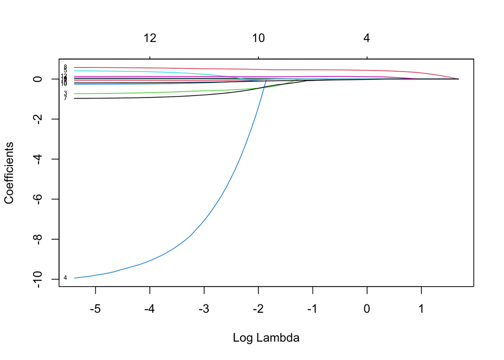

```r
fit.lasso=glmnet(x,y)
plot(fit.lasso,xvar="lambda",label=TRUE)
```

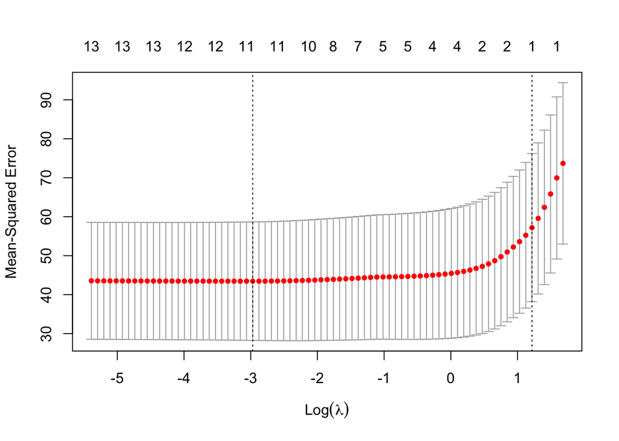

```r
cv.lasso=cv.glmnet(x,y)
plot(cv.lasso)
```

```r
coef(cv.lasso)
```

```
## 14 x 1 sparse Matrix of class "dgCMatrix"
##                     1
## (Intercept) 1.4186415
## zn          .
## indus       .
## chas        .
## nox         .
## rm          .
## age         .
## dis         .
## rad         0.2298449
## tax         .
## ptratio     .
## black       .
## lstat       .
## medv        .
```

Suppose we want to use our earlier train/validation division to select the `lambda` for the lasso. This is easy to do.

```r
lasso.tr=glmnet(x[train,],y[train])
lasso.tr
```

```
##
## Call:  glmnet(x = x[train, ], y = y[train])
##
##    Df  %Dev Lambda
## 1   0  0.00 5.1500
## 2   1  7.65 4.6920
## 3   1 14.00 4.2750
## 4   1 19.27 3.8960
## 5   1 23.65 3.5500
## 6   1 27.29 3.2340
## 7   1 30.30 2.9470
## 8   2 32.99 2.6850
## 9   2 35.76 2.4470
## 10  2 38.07 2.2290
## 11  3 40.20 2.0310
```

[output cut: 65 more lines]

```r
pred=predict(lasso.tr,x[-train,])
dim(pred)
```

```
## [1] 253  76
```

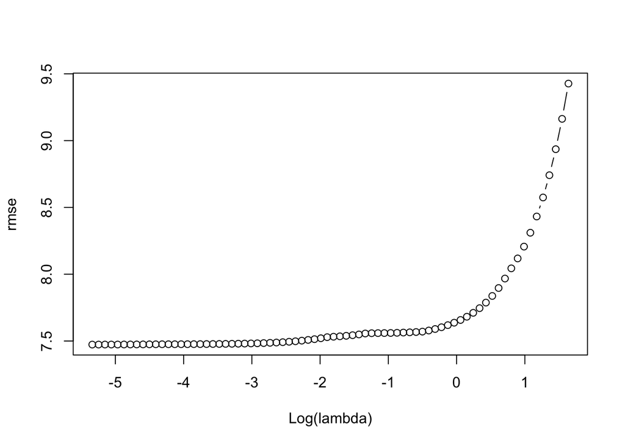

```r
rmse= sqrt(apply((y[-train]-pred)^2,2,mean))
plot(log(lasso.tr$lambda),rmse,type="b",xlab="Log(lambda)")
```

```r
lam.best=lasso.tr$lambda[order(rmse)[1]]
lam.best
```

```
## [1] 0.004802758
```

```r
coef(lasso.tr,s=lam.best)
```

```
## 14 x 1 sparse Matrix of class "dgCMatrix"
##                         1
## (Intercept)  2.491784e+01
## zn           3.573026e-02
## indus       -3.718848e-02
## chas        -1.025285e+00
## nox         -1.176895e+01
## rm          -9.986761e-01
## age          1.778807e-02
## dis         -7.260756e-01
## rad          4.881936e-01
## tax         -7.271479e-04
## ptratio     -2.413119e-01
## black       -1.749449e-02
## lstat        8.121491e-02
## medv        -7.961669e-02
```

# Principal Component Regression and Partial Least Square Regression

```r
library(pls)
set.seed(2)
pcr.fit=pcr(crim~.,data=Boston,scale=TRUE,validation="CV")
summary(pcr.fit)
```

```
## Data:    X dimension: 506 13
##  Y dimension: 506 1
## Fit method: svdpc
## Number of components considered: 13
##
## VALIDATION: RMSEP
## Cross-validated using 10 random segments.
##        (Intercept)  1 comps  2 comps  3 comps  4 comps  5 comps  6 comps
## CV            8.61    7.229    7.227    6.814    6.799    6.795    6.794
## adjCV         8.61    7.225    7.222    6.807    6.789    6.788    6.787
##        7 comps  8 comps  9 comps  10 comps  11 comps  12 comps  13 comps
## CV       6.787    6.654    6.664     6.673     6.676     6.651     6.573
## adjCV    6.780    6.645    6.656     6.664     6.666     6.639     6.562
##
## TRAINING: % variance explained
##       1 comps  2 comps  3 comps  4 comps  5 comps  6 comps  7 comps  8 comps
## X       47.70    60.36    69.67    76.45    82.99    88.00    91.14    93.45
## crim    30.69    30.87    39.27    39.61    39.61    39.86    40.14    42.47
##       9 comps  10 comps  11 comps  12 comps  13 comps
## X       95.40     97.04     98.46     99.52     100.0
## crim    42.55     42.78     43.04     44.13      45.4
```

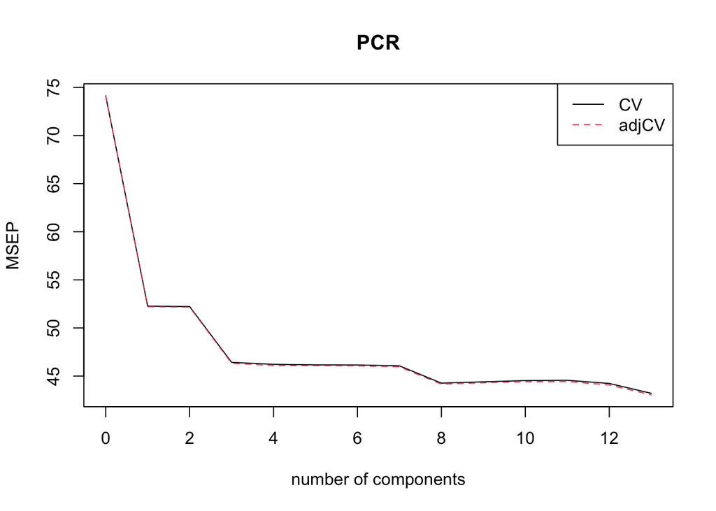

```r
validationplot(pcr.fit,val.type="MSEP",legendpos = "topright", main="PCR")
```

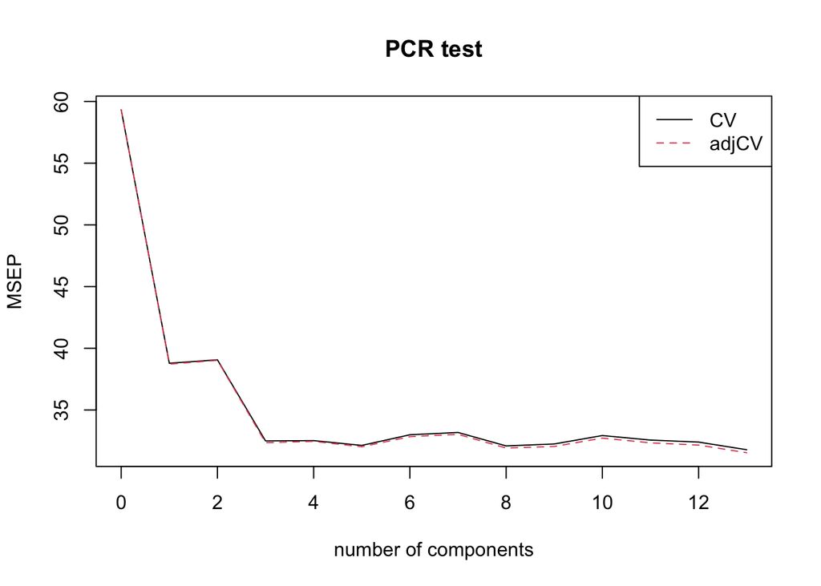

```r
set.seed(1)
pcr.fit=pcr(crim~.,data=Boston, subset=train,scale=TRUE, validation="CV")
validationplot(pcr.fit,val.type="MSEP",legendpos = "topright", main="PCR test")
```

```r
pcr.pred=predict(pcr.fit,x[-train,],ncomp=2)
mean((pcr.pred-y[-train])^2)
```

```
## [1] 64.97004
```

```r
pcr.fit=pcr(y~x,scale=TRUE,ncomp=2)
summary(pcr.fit)
```

```
## Data:    X dimension: 506 13
##  Y dimension: 506 1
## Fit method: svdpc
## Number of components considered: 2
## TRAINING: % variance explained
##    1 comps  2 comps
## X    47.70    60.36
## y    30.69    30.87
```

```r
set.seed(1)
pls.fit=plsr(crim~.,data=Boston, subset=train, scale=TRUE, validation="CV")
summary(pls.fit)
```

```
## Data:    X dimension: 253 13
##  Y dimension: 253 1
## Fit method: kernelpls
## Number of components considered: 13
##
## VALIDATION: RMSEP
## Cross-validated using 10 random segments.
##        (Intercept)  1 comps  2 comps  3 comps  4 comps  5 comps  6 comps
## CV           7.702    6.025    5.651    5.684    5.690    5.653    5.636
## adjCV        7.702    6.018    5.639    5.662    5.667    5.633    5.615
##        7 comps  8 comps  9 comps  10 comps  11 comps  12 comps  13 comps
## CV       5.656    5.649    5.632     5.636     5.638     5.637     5.637
## adjCV    5.633    5.626    5.611     5.614     5.616     5.616     5.616
##
## TRAINING: % variance explained
##       1 comps  2 comps  3 comps  4 comps  5 comps  6 comps  7 comps  8 comps
## X       47.66    57.52    62.37    71.11    77.71    79.84    84.08    87.86
## crim    41.21    50.60    52.50    53.04    53.28    53.58    53.64    53.68
##       9 comps  10 comps  11 comps  12 comps  13 comps
## X       89.89     93.70     96.55     98.42    100.00
## crim    53.69     53.69     53.69     53.69     53.69
```

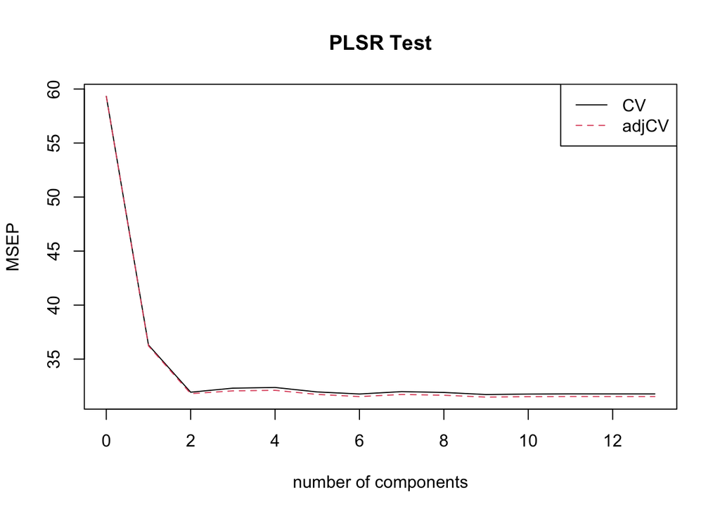

```r
validationplot(pls.fit,val.type="MSEP", legendpos = "topright", main="PLSR Test")
```

```r
pls.pred=predict(pls.fit,x[-train,],ncomp=2)
mean((pls.pred-y[-train])^2)
```

```
## [1] 58.26538
```

```r
pls.fit=plsr(crim~.,data=Boston,scale=TRUE,ncomp=2)
summary(pls.fit)
```

```
## Data:    X dimension: 506 13
##  Y dimension: 506 1
## Fit method: kernelpls
## Number of components considered: 2
## TRAINING: % variance explained
##       1 comps  2 comps
## X       47.27    56.79
## crim    34.32    41.81
```